# ps_8

Arnav Srivastava

4/13/2020

## Question 1: Conduct exploratory data analysis

1a) Summary Statistics

Data summary

| Name | Piped data |
| --- | --- |
| Number of rows | 4929 |
| Number of columns | 2 |
| _______________________ |  |
| Column type frequency: |  |
| numeric | 2 |
| ________________________ |  |
| Group variables | None |

**Variable type: numeric**

| skim_variable | n_missing | complete_rate | mean | sd | p0 | p25 | p50 | p75 | p100 | hist |
| --- | --- | --- | --- | --- | --- | --- | --- | --- | --- | --- |
| total_tweets | 0 | 1 | 19.73 | 28.41 | 0.0 | 0.0 | 0 | 41 | 109 | ▇▁▂▁▁ |
| approve | 0 | 1 | 41.36 | 4.08 | 23.9 | 38.1 | 41 | 44 | 59 | ▁▂▇▃▁ |

1B) Bivariate correlations

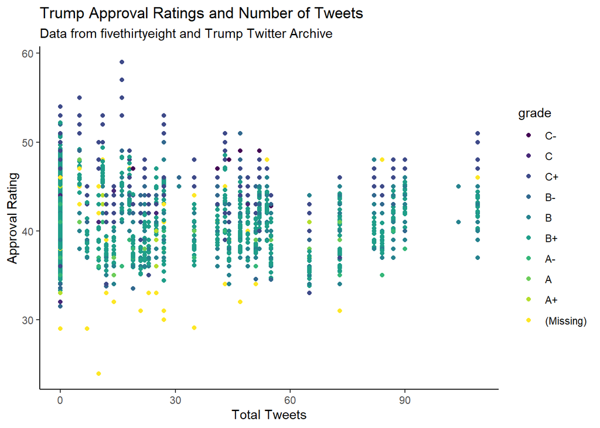

## Question 2: Run a multivariate regression

2A) Using lm()

Effect of Number of Tweets and Poll Quality on Reported Approval Rating

Data from fivethirtyeight and Trump Tweet Archive

| Variable | Estimate | Lower bound | Higher bound |
| --- | --- | --- | --- |
| (Intercept) | 41.603346208 | 41.462416251 | 41.7442761649 |
| total_tweets | -0.004290405 | -0.008255407 | -0.0003254025 |
| high_q | -2.347202071 | -2.792291035 | -1.9021131066 |

2C) Interaction Variables

Effect of Number of Tweets and Poll Quality on Reported Approval Rating

Data from fivethirtyeight and Trump Tweet Archive

| Variable | Estimate | Lower bound | Higher bound |
| --- | --- | --- | --- |
| (Intercept) | 41.629177904 | 41.486836544 | 41.771519264 |
| total_tweets | -0.005586465 | -0.009680749 | -0.001492181 |
| high_q | -2.701455717 | -3.227721585 | -2.175189848 |
| total_tweets:high_q | 0.020531555 | 0.004235733 | 0.036827376 |

2D) Estimating Fitted Values

```r
# based on our table above, the intercept of a approval vs. high quality poll is
# (41.629177904 - 2.701455717). The slope of this same line is (-0.005586465 +
# 0.020531555). Therefore, plugging intercept for b and slope for m in the
# linear equation y = mx + b, we can approximate the approval rating based on 84
# tweets that week

(-0.005586465 + 0.020531555)*(84) + (41.629177904 - 2.701455717)
```

```
## [1] 40.18311
```

```r
# we know compare our value calculated using the fitted value feature of
# augment(), selecting for total_tweets = 84 and high_q polls only, which is the
# criteria we tested our model on. We can slice just slice the first value since
# all fitted values are the same given the criteria we selected for regardless
# of who conducted the poll or when it occurred.

lm(approve ~ total_tweets * high_q, data = twoll) %>%
  augment() %>%
  filter(total_tweets == 84 & high_q == 1) %>%
  slice(1) %>%
  select(.fitted)
```

```
## # A tibble: 1 x 1
##   .fitted
##     <dbl>
## 1    40.2
```

2E) Multiple Regression and the Rubin Causal Model

The following is an explanatory model, as we do in fact care about which factors in specific affect approval ratings and how specific dynamics such as party-affiliations along with tweet volume affect approval. We are not only concerned about predicting the impact of tweets on approval, but are interested in the mechanism of how tweets influence different parties. Since the desired regression is a parallel slopes model, we see that all 3 lines will have the same slope but different y-intercepts. In particular, this model assumes that total_tweets has the same correlation coefficient with respect to approval ratings, and democrats and total_tweets:democrats have this same exact coefficient as well. This model suggests that as the number of tweets in a week increases, the rate of change in all 3 variables increases/decreases at the same rate; however, variables with a higher y-intercept have a greater impact on approval rating. Therefore, one variable will have more emphasis on determining approval ratings than other variables regardless of voter count. Nevertheless, our parallel slope model tells us the influence and emphasis of specific variables such as being Democrat have on tweet-volume-based approval rates.

## Question 3: Generalize to many regressions

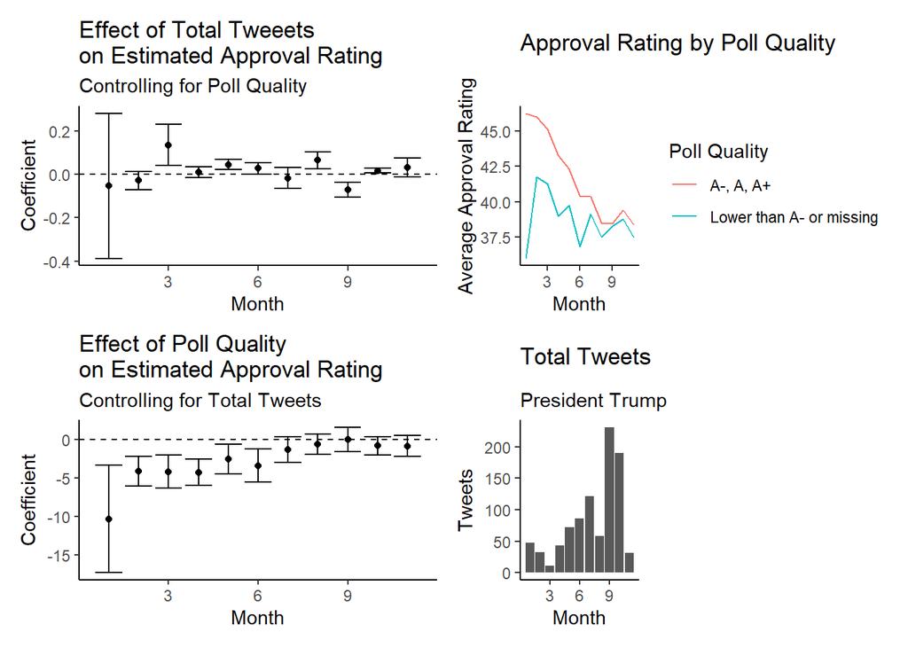

Collaborators: None.